[figure not shown]

rtweetrtweet

Kyle BrewsterKyle Brewster

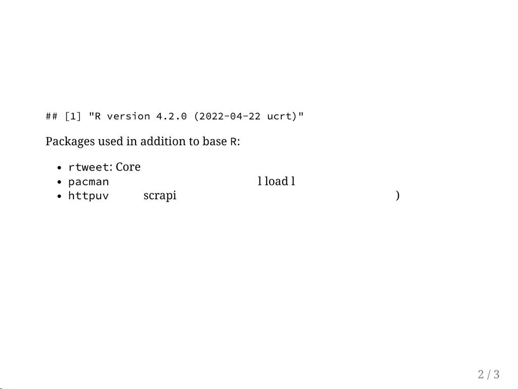

Introduction

Presentation and code composed in

## [1] "R version 4.2.0 (2022-04-22 ucrt)"

Packages used in addition to base

R

:

rtweet

: Core package

pacman

: Package manager to install/load libraries

httpuv

: Web-scraping capabilities (just needs to be installed)

2 / 33

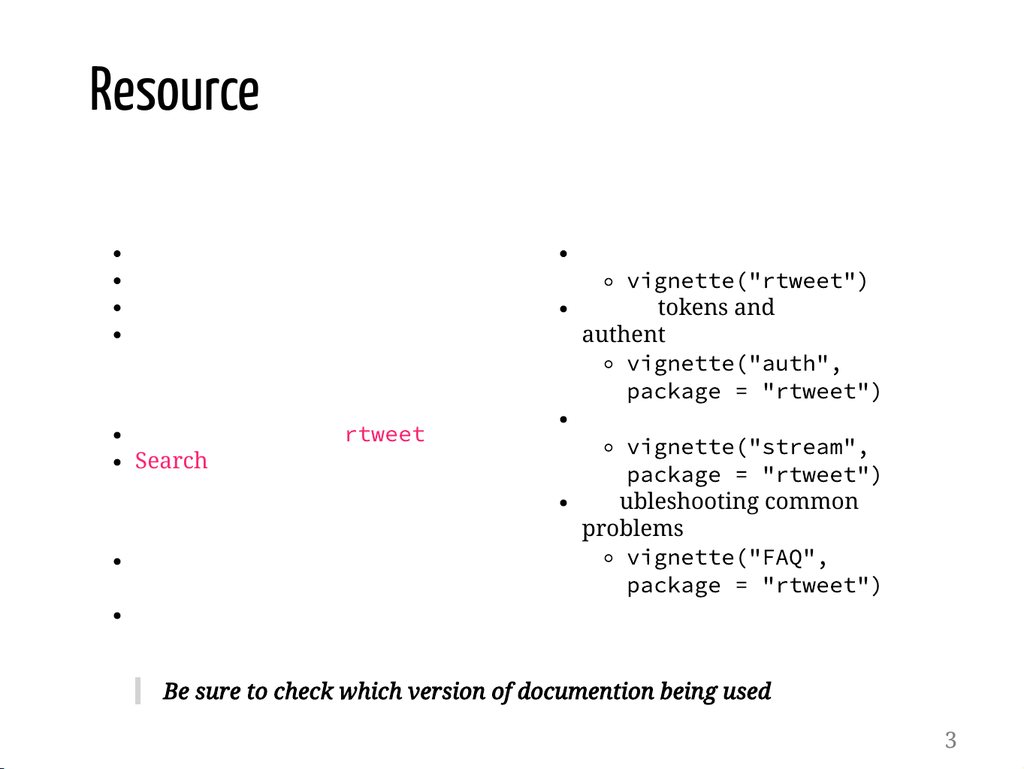

Package Documentation

R OpenSci

CRAN

RDocumentation

Github

Usage Tutorials

Slides by Author of

rtweet

Searching Twitter with rtweet

Twitter

Developer Platform API

Reference Index

Guides & Reference for

Developer Platform

Vignettes

Intro to rtweet

vignette("rtweet")

Access tokens and

authentication

vignette("auth",

package = "rtweet")

Live streaming tweets

vignette("stream",

package = "rtweet")

Troubleshooting common

problems

vignette("FAQ",

package = "rtweet")

Resources

Be sure to check which version of documention being used

3 / 33

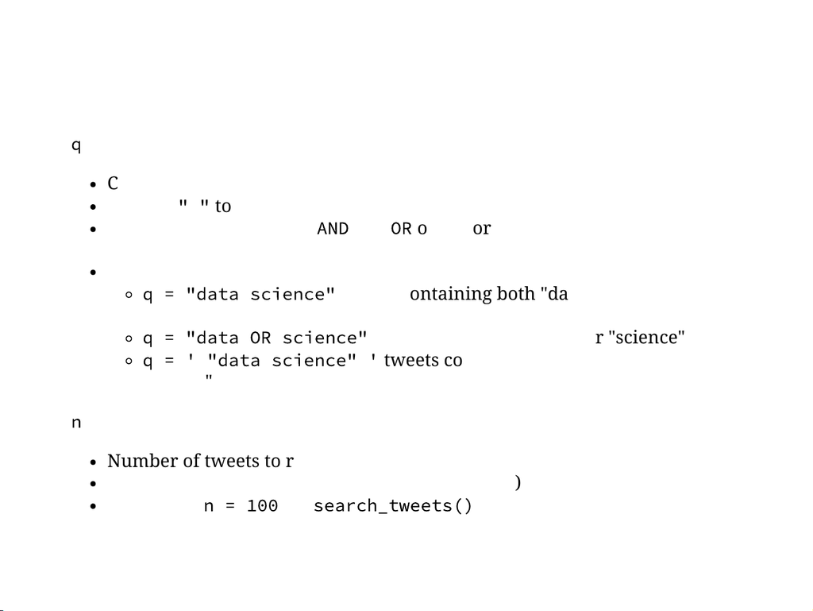

Basic Arguments

q

Character string used to define search parameters

Can use

" "

to enclose string

Also recognizes boolean

AND

and

OR

operators; Search exact phrases with

double-quotes

Ex:

q = "data science"

tweets containing both "data" and "science" in

any order

q = "data OR science"

tweets containing "data" or "science"

q = ' "data science" '

tweets containing the exact phrase "data

science"

n

Number of tweets to return

Low values suggested for sandbox development)

Defaults at

n = 100

for

search_tweets()

4 / 33

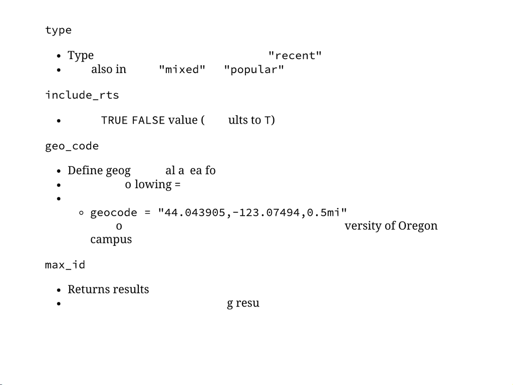

type

Type of tweets to include (defaults to

"recent"

)

Can also include

"mixed"

or

"popular"

include_rts

Takes

TRUE

/

FALSE

value (defaults to

T

)

geo_code

Define geographical area for searches

Template following

=

sign is "latitude, longitude, radius"

Ex:

geocode = "44.043905,-123.07494,0.5mi"

would be an

approximation for the Twittersphere of the University of Oregon

campus

max_id

Returns results with ID less than (or equal to) specified value

i.e. Additional layer of filtering results by time

5 / 33

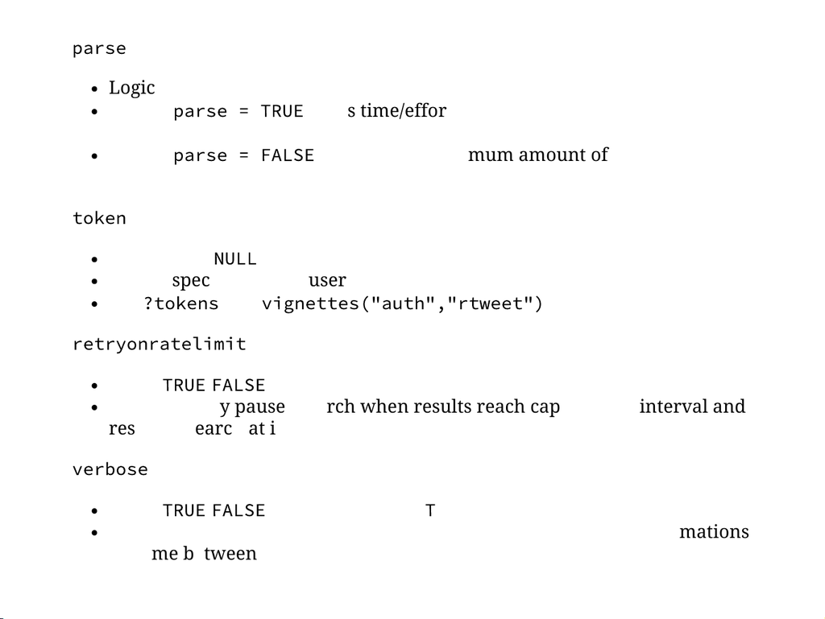

parse

Logical indicator to determine whether to return parsed data.frame

Setting

parse = TRUE

saves time/effort of manually navigating return

lists

Setting

parse = FALSE

ensures the maximum amount of possible

information is returned

token

Set equal to

NULL

by default

Allows specification of user app; often stored as environmental variable

See

?tokens

and

vignettes("auth","rtweet")

for more

retryonratelimit

Takes

TRUE

/

FALSE

value

Automatically pauses search when results reach cap for time interval and

resumes search at interval refresh

verbose

Takes

TRUE

/

FALSE

value (defaults to

T

)

Defines if to include output processing/retrieval messages (i.e. estimations

for time between searches)

6 / 33

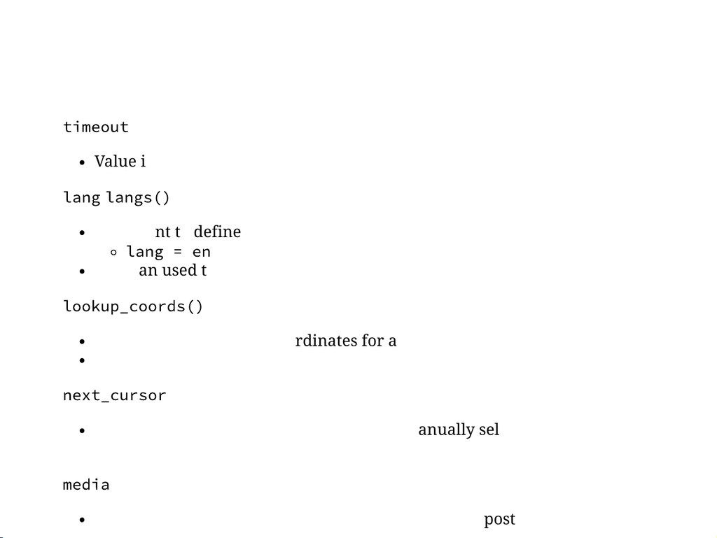

Other Useful Arguments

timeout

Value in seconds to define when to stop searching

lang

/

langs()

Argument to define language parameters

lang = en

for English

Also can used to call database of languages from the Library of Congress

lookup_coords()

Gets latitude/longitude coordinates for a specified location

Able to be used as an independent function

next_cursor

Goes to next pages of results/items when manually selecting next would

otherwise be required

media

Specify file path for media to be included in tweets, posts, and etc.

7 / 33

[figure not shown]

What is

rtweet

?

A technical definition:

"An implementation of calls designed to collect and organize

Twitter data via Twitter's REST and stream Application Program

Interfaces (API)"

Recall that APIs are sets of protocols that govern interactions between

sites and users

Web browsers render content while APIs manage & organize data

Simply put,

rtweet

allows use to retrieve real-time information from all

publicly available data in the Twitterverse and provides options for

interacting with Twitter via an authorized account

8 / 33

[figure not shown]

A Quick Lesson in Twitter

Defining and redefining some words according to the Twitter Glossary of

Terms

Twitterverse: the collective reference to all things relating to Twitter

Retweet:

(n.) A non-original tweet that was shared on your timeline;

(v.) Sharing another account's Tweet to followers; a tweet is the post

itself or the act of posting

Likes: previously referred to as favorites, changed as of 2015; terms are

synonymous

Hashtag: text following a

#

symbol; denotes keywords, topics, and/or

trends associated

Timeline: a real-time stream of Tweets; your home timeline displays all

tweets those you follow

Trend: a topic/hashtag algorithmically determined by Twitter to be

"popular" at the moment

Friends: Accounts/users that a specific user follows

9 / 33

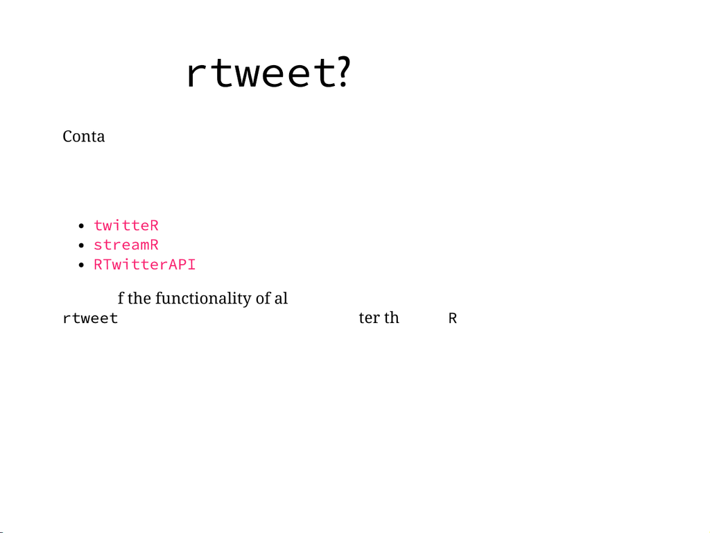

Why use

rtweet

?

Contains greater functionality compared to other R packages for accessing

and interacting with Twitter's APIs

Other similar packages include:

twitteR

streamR

RTwitterAPI

Much of the functionality of alternative packages are outdated, so plan to use

rtweet

whenever interacting with Twitter through

R

10 / 33

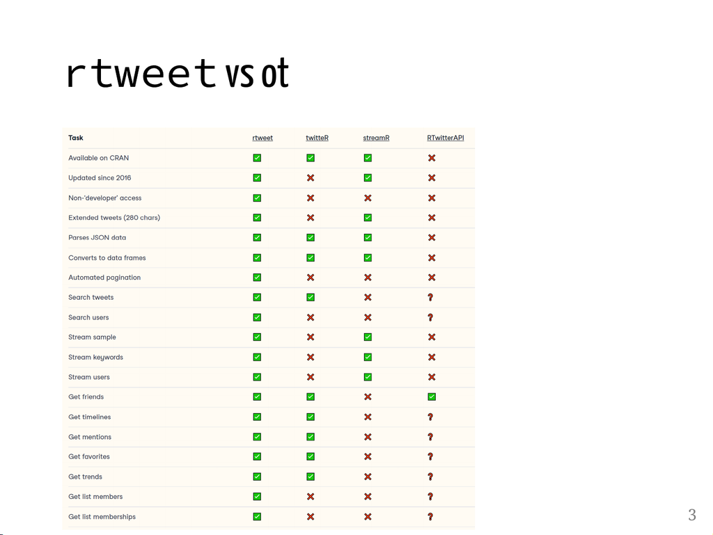

rtweet

vs other Packages

11 / 33

Terms of Use

Use in accordance with Twitter's developer terms and conditions of use

Likely won't matter in the classroom, but would be important to consider if

working with or sharing large amounts of data, using in a professional

environment, using as a developer, or planning to program automation

Examples of term violations include:

Use, storage, and/or sharing of sensitive information

Certain unauthorized redistribution of content

Creating spam or certain automated interactions with Twitter

Surveillance or other forms of privacy invasion

12 / 33

[figure not shown]

User Authentication

In order to interact with Twitter APIs via

rtweet

, you need to first become an

authenticated user. You will need to have a Twitter account. If you do not

have an account, you can sign up for one here

There are two methods to become an authorized user

1. Authentication through package-app called

rstats2twitter

2. Creating your own application (done via the Twitter Developer Portal)

Authentication must happen prior to being able to run any package

commands

13 / 33

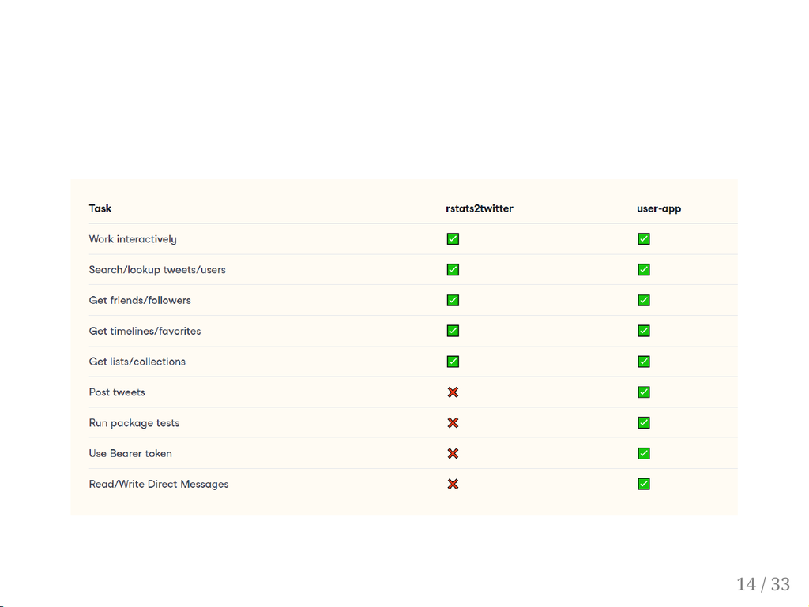

Functionality of Authentication Methods

Compared

Read more about current Twitter API interaction limitations and access levels

here

14 / 33

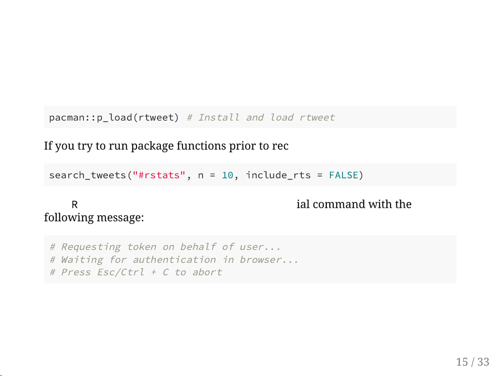

The Setup

First, Install packages

pacman::p_load(rtweet)

# Install and load rtweet

If you try to run package functions prior to receiving authentication

search_tweets("#rstats", n = 10, include_rts = FALSE)

Your

R

session will paused after running the initial command with the

following message:

# Requesting token on behalf of user...

# Waiting for authentication in browser...

# Press Esc/Ctrl + C to abort

15 / 33

[figure not shown]

You should be automatically redirected to Twitter with a request to authorize

the

rstats2twitter

app

Congratulations! You are now set up to use

rtweet

16 / 33

[figure not shown]

Creating a User App

Creating a user-app to authenticate as a user requires a few additional setup

steps, but provides better functionality and less oversight as a script

The Twitter Developer Portal is where you can configure apps for interacting

with Twitter's APIs

https://developer.twitter.com/apps

Note: Can only create three (3) user applications per 24-hour period per

account

17 / 33

[figure not shown]

Once verified and fully logged in, you should arrive at the dashboard

18 / 33

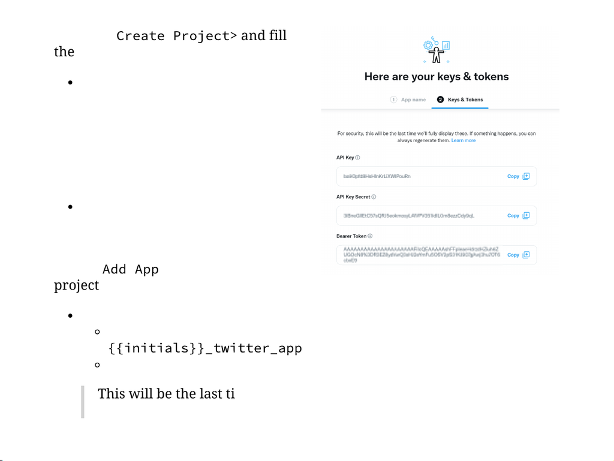

Click on <

Create Project

> and fill

the required text-fields

Assign a name, describe intent

for use, provide project

description

You will be automatically taken to a

section to create an application

under your new project

Could also open existing project

from Twitter Developer

Dashboard home

Select <

Add App

> from desired

project

Give your app a unique name

Suggested:

{{initials}}_twitter_app

Keep note of the keys

This will be the last time you are able to see all of this information

(unless you regenerate new keys or create a new app)

19 / 33

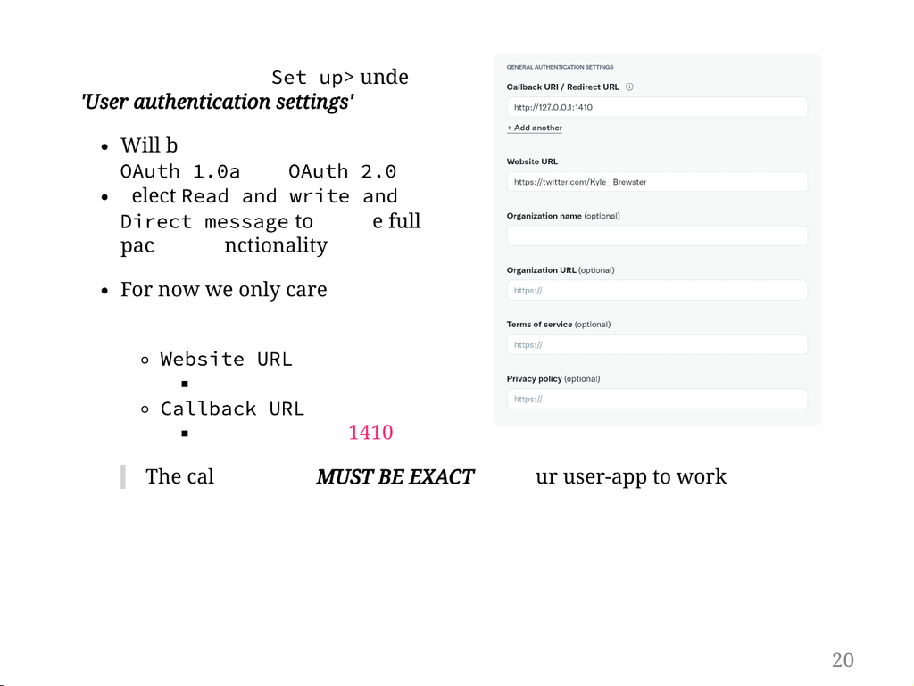

After creating the app, open the app

settings and select <

Set up

> under

'User authentication settings'

Will be given option to select

OAuth 1.0a

and

OAuth 2.0

Select

Read and write and

Direct message

to enable full

package functionality

For now we only care about two

fields

Website URL

https://twitter.com/{{your_screen_name}}

Callback URL

http://127.0.0.1:1410

The callback URL MUST BE EXACT for your user-app to work

20 / 33

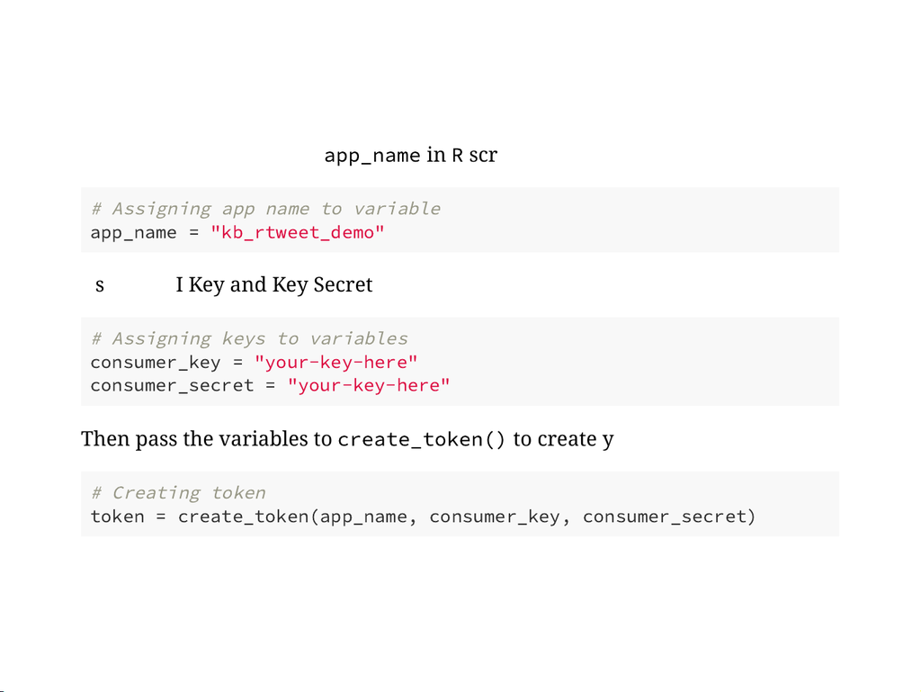

Back to the Console

Store the name of app as

app_name

in

R

script

# Assigning app name to variable

app_name = "kb_rtweet_demo"

Assign API Key and Key Secret

# Assigning keys to variables

consumer_key = "your-key-here"

consumer_secret = "your-key-here"

Then pass the variables to

create_token()

to create your own token

# Creating token

token = create_token(app_name, consumer_key, consumer_secret)

21 / 33

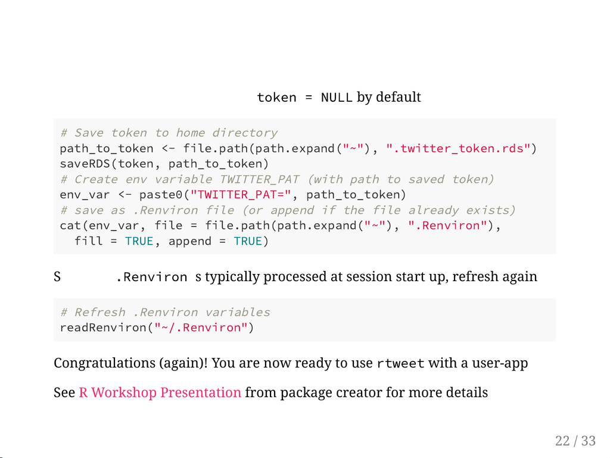

You can save yourself some future effort by storing your token as an

environmental variable

Otherwise will need to be manually specified for each function if intended to

authenticate via user-app since

token = NULL

by default

# Save token to home directory

path_to_token <- file.path(path.expand("~"), ".twitter_token.rds")

saveRDS(token, path_to_token)

# Create env variable TWITTER_PAT (with path to saved token)

env_var <- paste0("TWITTER_PAT=", path_to_token)

# save as .Renviron file (or append if the file already exists)

cat(env_var, file = file.path(path.expand("~"), ".Renviron"),

fill = TRUE, append = TRUE)

Since the

.Renviron

is typically processed at session start up, refresh again

# Refresh .Renviron variables

readRenviron("~/.Renviron")

Congratulations (again)! You are now ready to use

rtweet

with a user-app

See R Workshop Presentation from package creator for more details

22 / 33

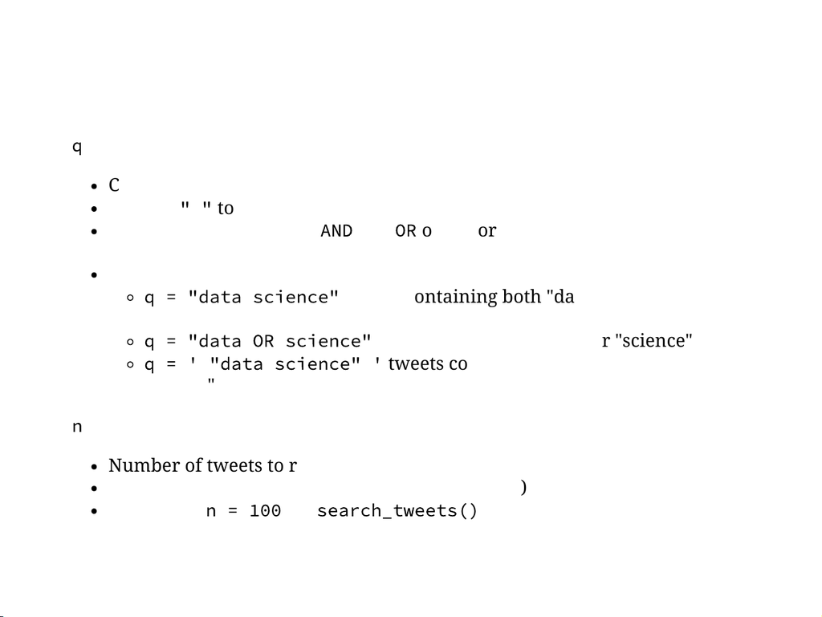

Basic Arguments

q

Character string used to define search parameters

Can use

" "

to enclose string

Also recognizes boolean

AND

and

OR

operators; Search exact phrases with

double-quotes

Ex:

q = "data science"

tweets containing both "data" and "science" in

any order

q = "data OR science"

tweets containing "data" or "science"

q = ' "data science" '

tweets containing the exact phrase "data

science"

n

Number of tweets to return

Low values suggested for sandbox development)

Defaults at

n = 100

for

search_tweets()

23 / 33

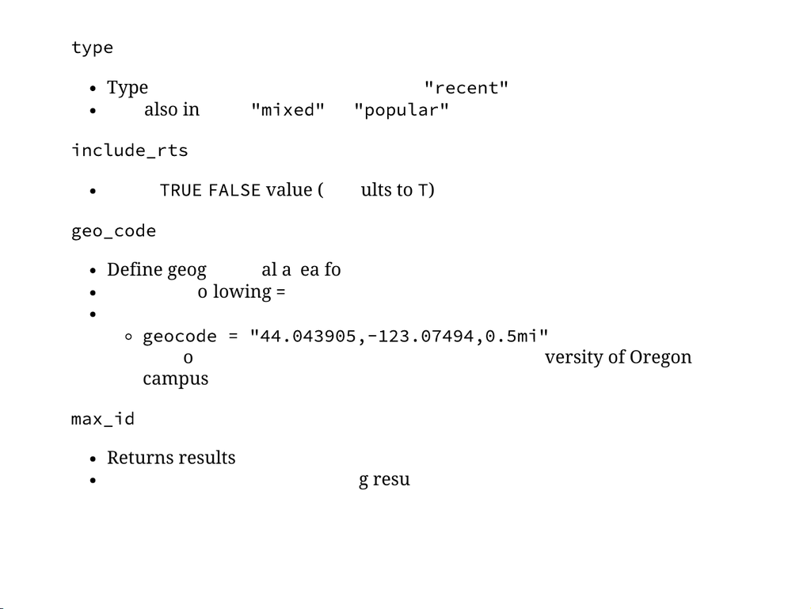

type

Type of tweets to include (defaults to

"recent"

)

Can also include

"mixed"

or

"popular"

include_rts

Takes

TRUE

/

FALSE

value (defaults to

T

)

geo_code

Define geographical area for searches

Template following

=

sign is "latitude, longitude, radius"

Ex:

geocode = "44.043905,-123.07494,0.5mi"

would be an

approximation for the Twittersphere of the University of Oregon

campus

max_id

Returns results with ID less than (or equal to) specified value

i.e. Additional layer of filtering results by time

24 / 33

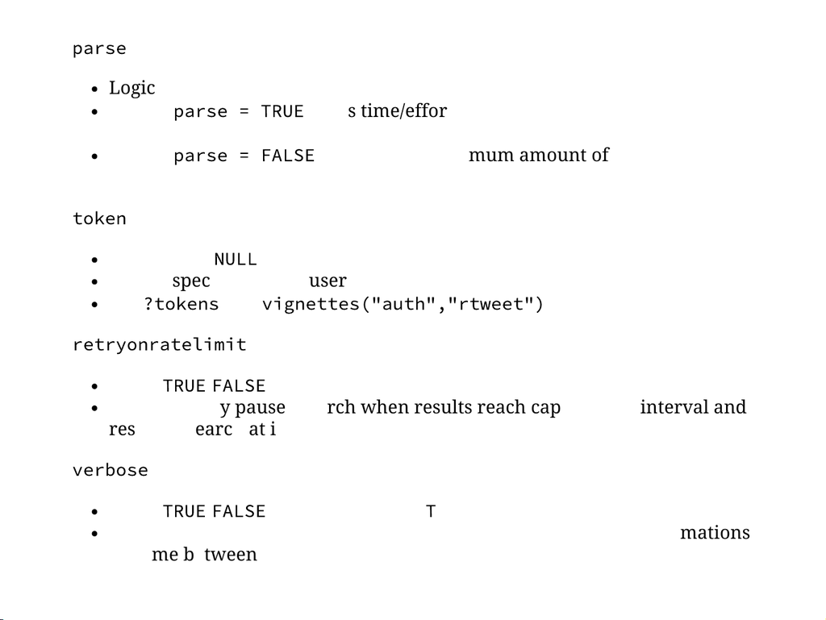

parse

Logical indicator to determine whether to return parsed data.frame

Setting

parse = TRUE

saves time/effort of manually navigating return

lists

Setting

parse = FALSE

ensures the maximum amount of possible

information is returned

token

Set equal to

NULL

by default

Allows specification of user app; often stored as environmental variable

See

?tokens

and

vignettes("auth","rtweet")

for more

retryonratelimit

Takes

TRUE

/

FALSE

value

Automatically pauses search when results reach cap for time interval and

resumes search at interval refresh

verbose

Takes

TRUE

/

FALSE

value (defaults to

T

)

Defines if to include output processing/retrieval messages (i.e. estimations

for time between searches)

25 / 33

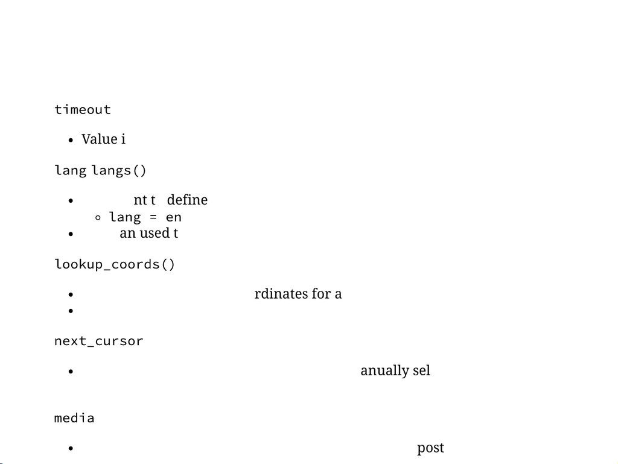

Other Useful Arguments

timeout

Value in seconds to define when to stop searching

lang

/

langs()

Argument to define language parameters

lang = en

for English

Also can used to call database of languages from the Library of Congress

lookup_coords()

Gets latitude/longitude coordinates for a specified location

Able to be used as an independent function

next_cursor

Goes to next pages of results/items when manually selecting next would

otherwise be required

media

Specify file path for media to be included in tweets, posts, and etc.

26 / 33

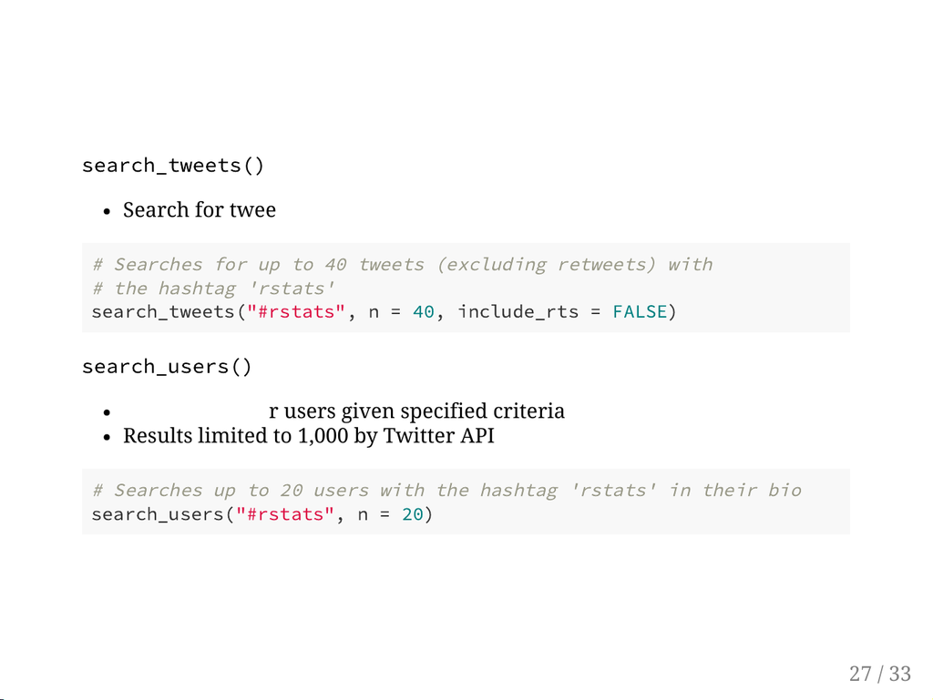

Functions & Functionality

search_tweets()

Search for tweets containing a specific hashtag up to a defined value

# Searches for up to 40 tweets (excluding retweets) with

# the hashtag 'rstats'

search_tweets("#rstats", n = 40, include_rts = FALSE)

search_users()

Basic search for users given specified criteria

Results limited to 1,000 by Twitter API

# Searches up to 20 users with the hashtag 'rstats' in their bio

search_users("#rstats", n = 20)

27 / 33

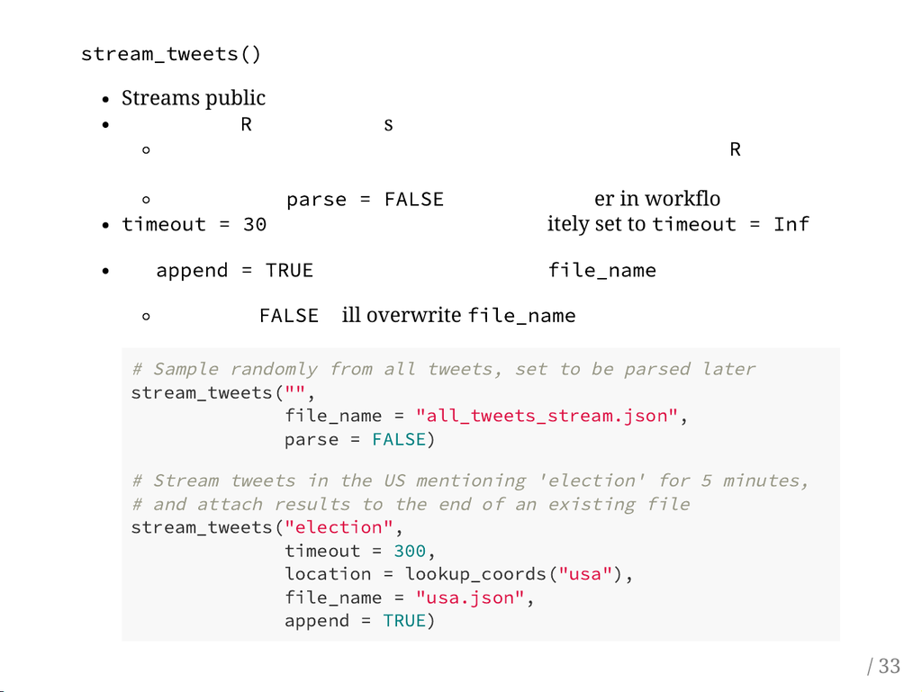

stream_tweets()

Streams public statues to a file

Will occupy

R

session until specified time has elapsed

Streaming itself takes little memory if running in a second

R

session,

but the parsing may result in computational strain

Solution: Set

parse = FALSE

to deal with later in workflow

timeout = 30

by default, to stream indefinitely set to

timeout = Inf

Set

append = TRUE

to attach stream to end

file_name

Setting to

FALSE

will overwrite

file_name

# Sample randomly from all tweets, set to be parsed later

stream_tweets("",

file_name = "all_tweets_stream.json",

parse = FALSE)

# Stream tweets in the US mentioning 'election' for 5 minutes,

# and attach results to the end of an existing file

stream_tweets("election",

timeout = 300,

location = lookup_coords("usa"),

file_name = "usa.json",

append = TRUE)

28 / 33

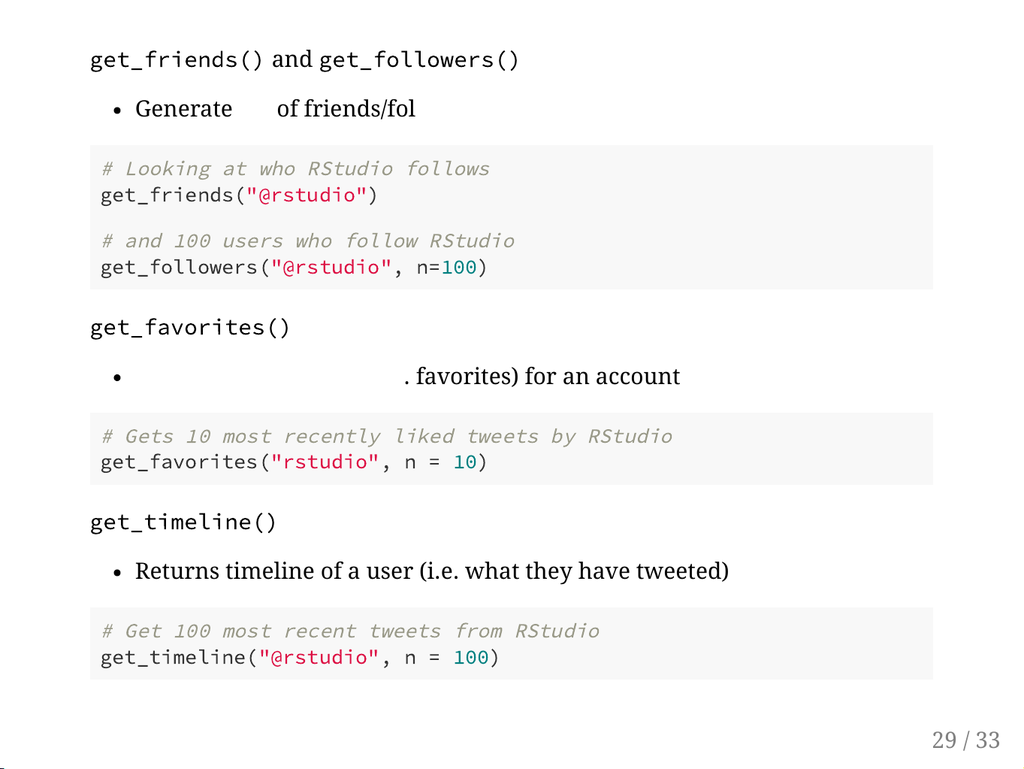

get_friends()

and

get_followers()

Generate list of friends/followers for a specified account

# Looking at who RStudio follows

get_friends("@rstudio")

# and 100 users who follow RStudio

get_followers("@rstudio", n=100)

get_favorites()

Obtain lists of likes (a.k.a. favorites) for an account

# Gets 10 most recently liked tweets by RStudio

get_favorites("rstudio", n = 10)

get_timeline()

Returns timeline of a user (i.e. what they have tweeted)

# Get 100 most recent tweets from RStudio

get_timeline("@rstudio", n = 100)

29 / 33

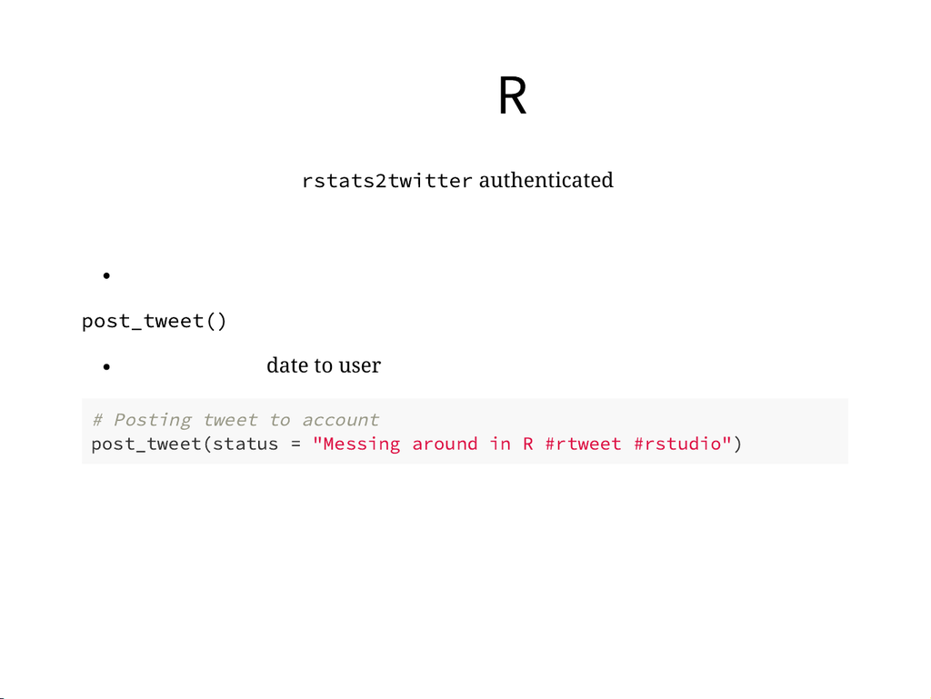

Account Actions via the

R

Console

Updates have allowed

rstats2twitter

authenticated users to utilize

additional functionality with the need to create a user-app with a Twitter

Developer account

Some online documentation may be incorrect/outdated

post_tweet()

Posts status update to user's Twitter account

# Posting tweet to account

post_tweet(status = "Messing around in R #rtweet #rstudio")

30 / 33

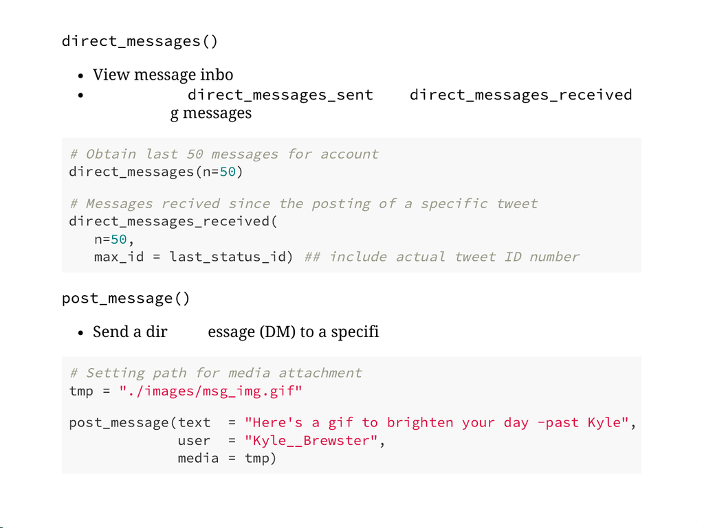

direct_messages()

View message inbox up to a specified number of messages

Can also use

direct_messages_sent

and

direct_messages_received

for filtering messages

# Obtain last 50 messages for account

direct_messages(n=50)

# Messages recived since the posting of a specific tweet

direct_messages_received(

n=50,

max_id = last_status_id)

## include actual tweet ID number

post_message()

Send a direct message (DM) to a specified recipient

# Setting path for media attachment

tmp = "./images/msg_img.gif"

post_message(text = "Here's a gif to brighten your day -past Kyle",

user = "Kyle__Brewster",

media = tmp)

31 / 33

Signicane for Economics?

On average:

200 billion tweets shared in a year

500 million tweets every day

350,000 tweets per minute

6,000 tweets per second

Well over 1 million tweets have been posted since beginning this

presentation

...That's a lot of data!

32 / 33

[figure not shown]

Final Thoughts

Remember you must have an internet connection

Getting all followers for a popular account could take several days

rtweet

allows use to derive interesting analysis from the Twitterverse

Helpful in understanding public opinion

Tracking specific trends/hashtags

Script over swiping gives us more options and and improved

scalability

Any API data usage restrictions are likely set by Twitter, don't blame

R

Keep usage in in mind if encountering issues

Keep an eye out for platform changes and package updates (or new

packages)

Some existing guides and resources contain inaccurate information since

Broken hyperlinks

Updates to

R

, the Twitter APIs, and/or the Twitter platform will

inevitably change functionality over time

Use ethically - "With great powers, comes great responsibility"

33 / 33